# Multi-Sample Tests and Randomization Test

**In this problem, you will analyze the Stat 100 survey 3 data in Fall 2015. The csv file can be downloaded here. The column variables are described on [this webpage](https://ytliu0.github.io/Stat390EF-R-Independent-Study-archive/RMarkdownExercises/Stat100_2015fall_survey03.html). The purpose of this exercise is to find out if there is any association between happiness (a person’s subjective well-being) and a person’s temperament (introvert/extrovert/ambirvert).**

### a. (2 points)

**Create box plots of `happiness` for the introverts, extroverts and ambiverts. Add the group means to the box plots.**

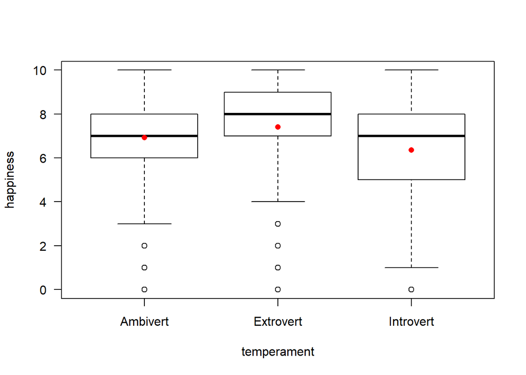

```r
# Load the data to R:
survey <- read.csv("Stat100_2015fall_survey03.csv")

# Create box plots
plot(happiness ~ temperament, data=survey, las=1)
# Calculate group means
group_means <- tapply(survey$happiness, survey$temperament, mean)
# Add group means with red points
points(group_means, col="red", pch=16)
```

### b. (3 points)

**Perform an F-test to determine if there are any significant differences on the reported scale of happiness among introverts, extroverts and ambiverts. (2 pts)**

The R command for the F-test is

```r
summary(aov(happiness ~ temperament, data=survey))
```

```
              Df Sum Sq Mean Sq F value   Pr(>F)
temperament    2    128   64.05   13.64 1.43e-06 ***
Residuals   1042   4894    4.70
---
Signif. codes:  0 '***' 0.001 '**' 0.01 '*' 0.05 '.' 0.1 ' ' 1
```

**Report the p-value and state your conclusion. (1 pt)**

From the output, the p-value is 1.43×10<sup>-6</sup>. This means that at least one group is significantly different from the other.

### c. (4 points)

**Perform pairwise t-tests with Bonferroni correction to adjust the p-values. (2 pts)**

Pairwise t-tests with Bonferroni correction:

```r
pairwise.t.test(survey$happiness, survey$temperament, p.adjust="bonferroni")
```

```
    Pairwise comparisons using t tests with pooled SD

data:  survey$happiness and survey$temperament

          Ambivert Extrovert
Extrovert 0.0164   -
Introvert 0.0016   7.4e-07

P value adjustment method: bonferroni
```

**Determine from the adjusted p-values which pairs of groups show significant differences at the 5% level. (2 pts)**

All of the adjusted p-values are less than 5%, which means that all pairs of groups show significant differences at the 5% level.

### d. (5 points)

**Perform a randomization test by scrambling the `happiness` variable and calculate the values of R<sup>2</sup> of the scrambled data. Repeat the experiment at least 5000 times. (3 pts)**

**Note: The result of your randomization test must be *reproducible*. Therefore, you must set a seed number before calling any function involving random numbers. Use `set.seed(your UIN number)`. You can simply follow the procedure in [this week’s notes](https://ytliu0.github.io/Stat390EF-R-Independent-Study-archive/Week11/ANOVA.html). You are not required to optimize the code.**

Following the same method as in [this week’s notes](https://ytliu0.github.io/Stat390EF-R-Independent-Study-archive/Week11/ANOVA.html), the code is as follows.

```r
# Define a function that computes R^2
computeR2 <- function(y,x) {
  summary(lm(y~x))$r.squared
}

# Compute the original R^2
(R20 <- computeR2(survey$happiness, survey$temperament))
```

```
[1] 0.02550464
```

```r
# Perform randomization test. Do 5000 experiments
set.seed(69678689)
R2 <- replicate(5000, computeR2(sample(survey$happiness),survey$temperament))
```

**Make a histogram of these R = $\sqrt{R^2}$ and indicate the position of the original R (from the unscrambled data). (2 pt)**

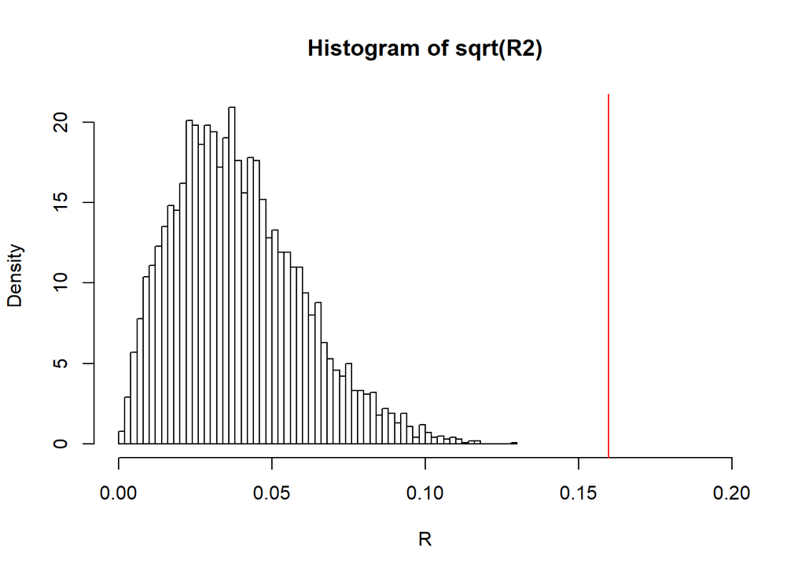

```r
hist(sqrt(R2), freq=FALSE,breaks=50, xlim=c(0,0.2), xlab="R")
# Add a vertical line at the position of the original R
abline(v=sqrt(R20), col="red")
```

### e. (3 points)

**Use the result of (d) to estimate the p-value. How does this estimated p-value compare to the one computed in part (b)?**

The estimated p-value is the fraction of the values in R2 greater than R20:

```r
(p_estimate <- mean(R2>R20))
```

```
[1] 0
```

The value is 0. This means that none of the 5000 values in R2 is greater than R20. So the estimated p-value is less than 1/5000 or 2×10<sup>-4</sup>. This is consistent with the p-value 1.43×10<sup>-6</sup> calculated from the F statistic in part (b).